# STAT 341/641 Homework 1

Firas Fakih

February 11th 2020

## Question 2: Compute a Covariance matrix

```r
covariance <- function(x){
  n = nrow(x)
  xcol = scale(x,center = TRUE,scale = FALSE)
  covar = t(xcol) %*% xcol/(n-1)
  return(covar)
}

library(tidyverse)
Diabetes <- read.csv(file = "/Users/firasfakih/Desktop/diabetes.csv")
# Diabetes data
names(Diabetes)
```

```
## [1] "Pregnancies"              "Glucose"
## [3] "BloodPressure"            "SkinThickness"
## [5] "Insulin"                  "BMI"
## [7] "DiabetesPedigreeFunction" "Age"
## [9] "Outcome"
```

```r
Diabetes <- Diabetes %>% select(BloodPressure,Glucose,BMI,Age)
covariance(Diabetes)
```

```
##               BloodPressure    Glucose      BMI       Age
## BloodPressure     374.64727   94.43096 43.00470  54.52345
## Glucose            94.43096 1022.24831 55.72699  99.08281
## BMI                43.00470   55.72699 62.15998   3.36033
## Age                54.52345   99.08281  3.36033 138.30305
```

```r
# Compare with cov function
cov(Diabetes)
```

```
##               BloodPressure    Glucose      BMI       Age
## BloodPressure     374.64727   94.43096 43.00470  54.52345
## Glucose            94.43096 1022.24831 55.72699  99.08281
## BMI                43.00470   55.72699 62.15998   3.36033
## Age                54.52345   99.08281  3.36033 138.30305
```

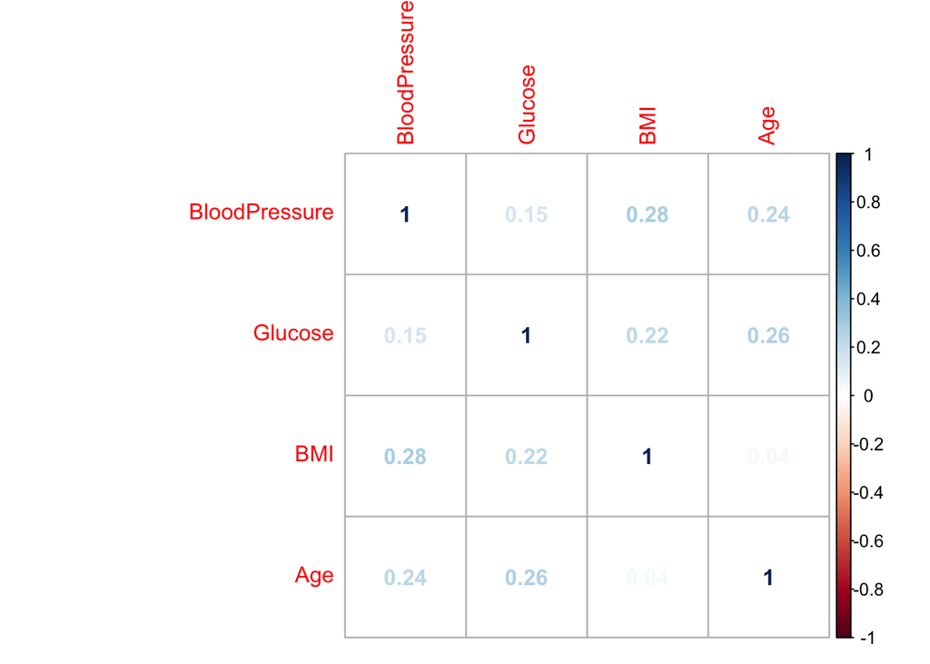

```r
install.packages("corrplot")
library(corrplot)
correlation <- cor(Diabetes)
corrplot(correlation,method = 'number')
```

```r
set.seed(34582)
ssize <- 100
diabetes_sample <- sample_n(Diabetes,ssize,replace = FALSE)
k <- ncol(diabetes_sample)
jackknife <- matrix(0,k,k)

for (i in 1:ssize) {
  jackknife = jackknife + cov(diabetes_sample[-i,])
}

# average jackknife value

jackvalue <- jackknife / ssize

# Compare

diff <- jackvalue - cov(diabetes_sample)

diff
```

```
##               BloodPressure      Glucose          BMI           Age
## BloodPressure  5.684342e-14 5.684342e-14 3.552714e-15  1.421085e-14
## Glucose        5.684342e-14 5.684342e-13 7.105427e-15  1.421085e-14
## BMI            3.552714e-15 7.105427e-15 2.842171e-14  1.776357e-15
## Age            1.421085e-14 1.421085e-14 1.776357e-15 -5.684342e-14
```

**Difference between jackknife value and actual value is close to 0** * * *

## Question 5 : Comparing variances in measures of central tendency

```r
set.seed(34582)
n <- 100
cn <- rcauchy(n)
mean(cn)
```

```
## [1] -1.079901
```

```r
median(cn)
```

```
## [1] -0.02747957
```

```r
alpha <- 0.1
mean(cn,trim = alpha)
```

```
## [1] -0.1631008
```

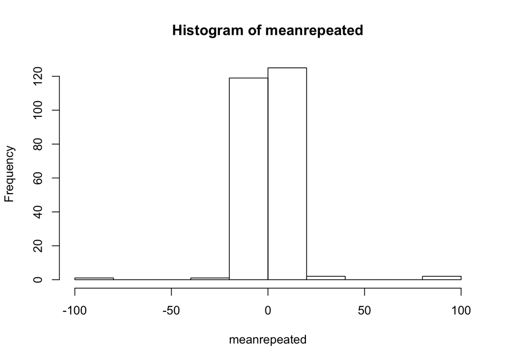

```r
#Repeat 250 times
Repeatntime <- 250
meanrepeated <- numeric(Repeatntime)
medianrepeated <- numeric(Repeatntime)
trimmedrepeated <- numeric(Repeatntime)
for (i in 1:Repeatntime) {
  n = 100
  nc = rcauchy(n)
  meanrepeated[i] = mean(nc)
  medianrepeated[i] = median(nc)
  trimmedrepeated[i] = mean(nc,trim = 0.1)
}
hist(meanrepeated)
```

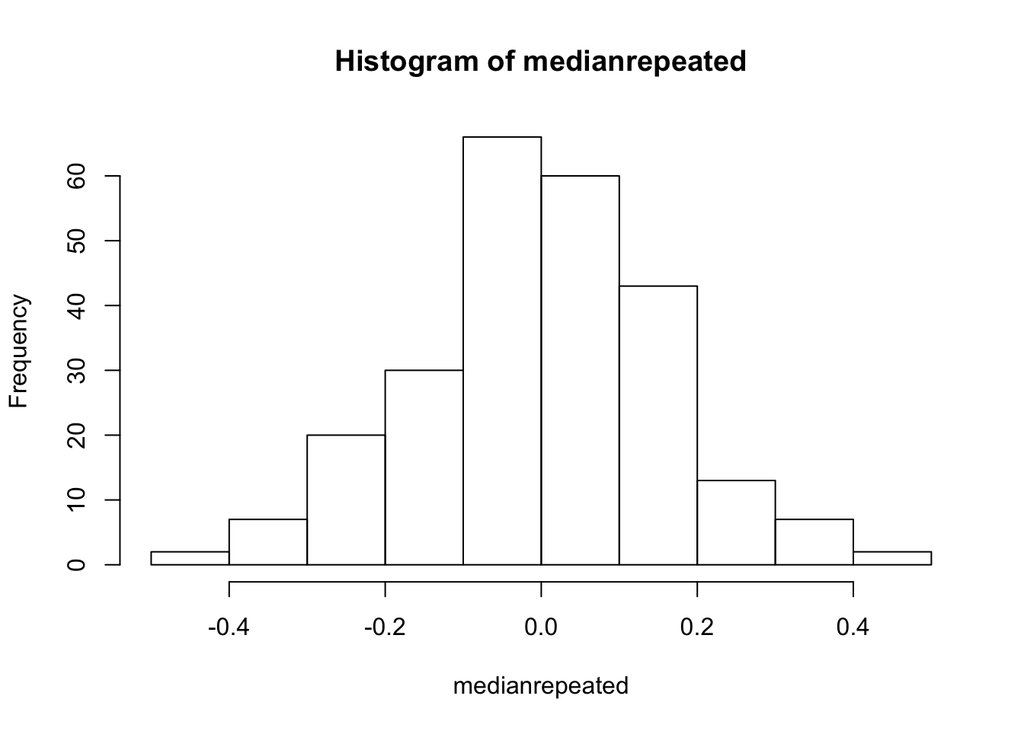

```r
hist(medianrepeated)
```

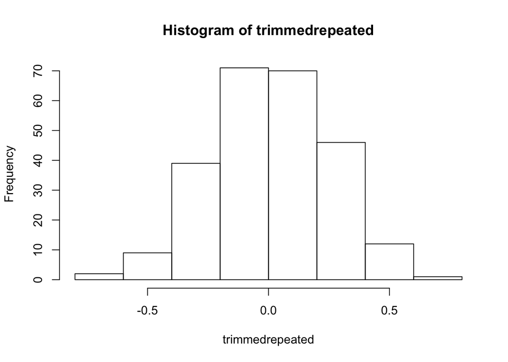

```r
hist(trimmedrepeated)
```

```r
var(meanrepeated)
```

```
## [1] 118.1223
```

```r
var(medianrepeated)
```

```
## [1] 0.02504178
```

```r
var(trimmedrepeated)
```

```
## [1] 0.05835327
```

**Obviously here we see that the median is the most robust estimator since it has the smallest variance**

## Question 6 : Comparing Variances in measure with the T distribution

```r
set.seed(34582)
n <- 100
x <- rt(n,df = 2)
mean(x)
```

```
## [1] 0.06687408
```

```r
median(x)
```

```
## [1] -0.08220159
```

```r
alpha <- 0.1
mean(x,trim = alpha)
```

```
## [1] -0.1324079
```

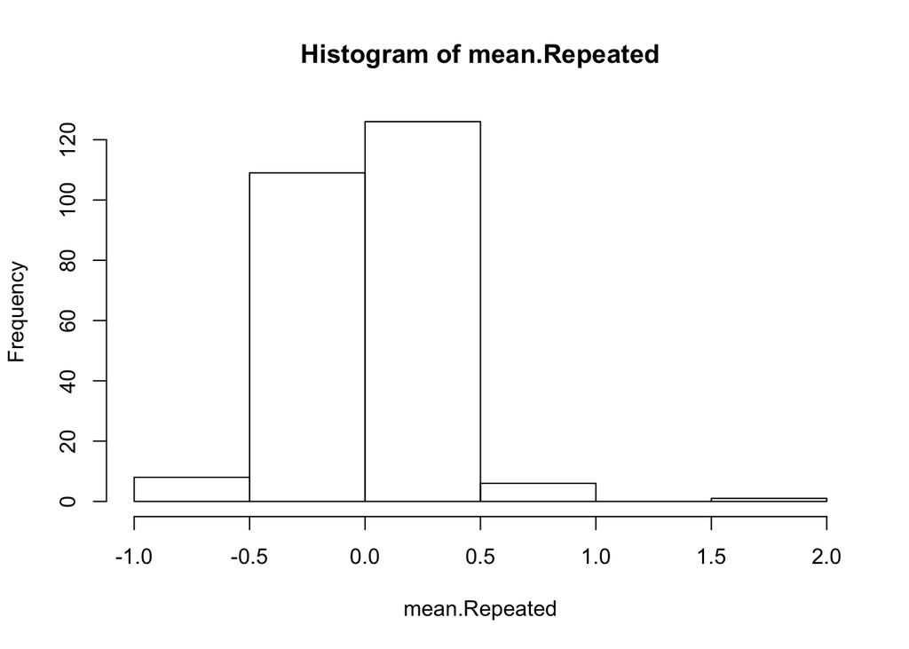

```r
# Repeat 250 times
Repeated <- 250
mean.Repeated <- numeric(Repeated)
median.repeated <- numeric(Repeated)
trimmed.repeated <- numeric(Repeated)
for (i in 1:Repeated) {
  n = 100
  x = rt(n,df = 2)
  mean.Repeated[i] = mean(x)
  median.repeated[i] = median(x)
  trimmed.repeated[i] = mean(x,trim = 0.1)
}
hist(mean.Repeated)
```

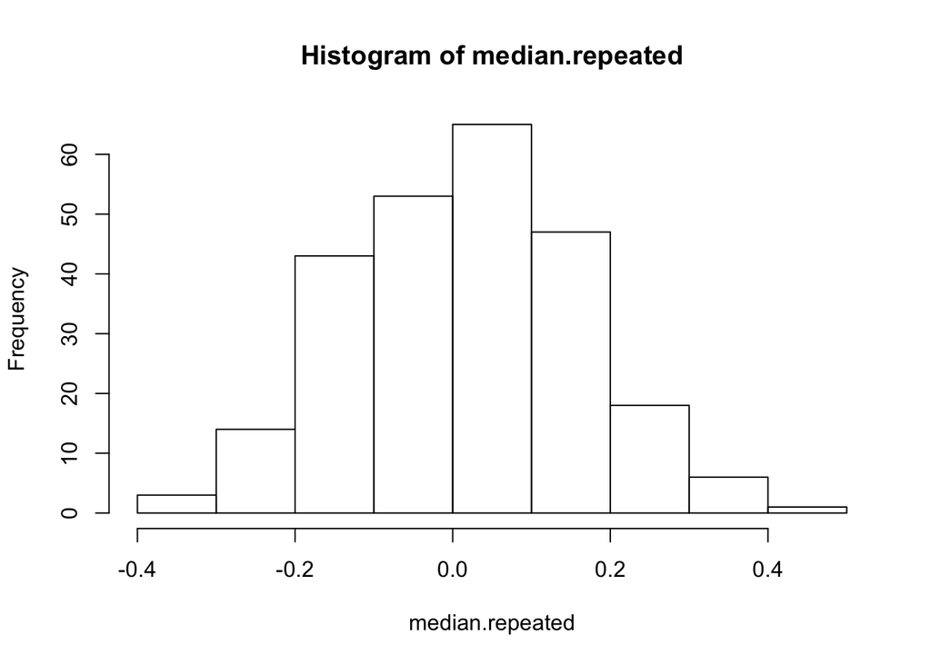

```r
hist(median.repeated)
```

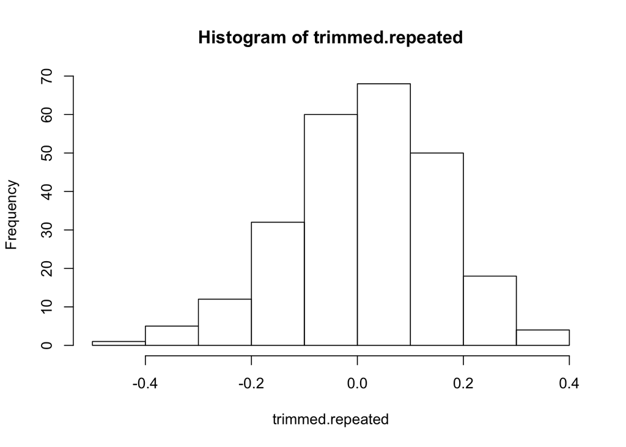

```r
hist(trimmed.repeated)
```

```r
var(mean.Repeated)
```

```
## [1] 0.08607286
```

```r
var(median.repeated)
```

```
## [1] 0.02084361
```

```r
var(trimmed.repeated)
```

```
## [1] 0.02044413
```

## Question 7: Local Outlier Factor vs Isolation Forest

```r
outlier.data <- read_csv(file = "/Users/firasfakih/Desktop/outlier_set.csv")
outlier.data <- outlier.data[,-1]
install.packages("Rlof")
library(Rlof)
Lof <- lof(outlier.data,k = 5)
library(solitude)
isf <- isolationForest$new(sample_size = ceiling(nrow(outlier.data)))
isf$fit(outlier.data)
```

```
## Building Isolation Forest ...
```

```
## done
```

```
## Computing depth of terminal nodes ... done
```

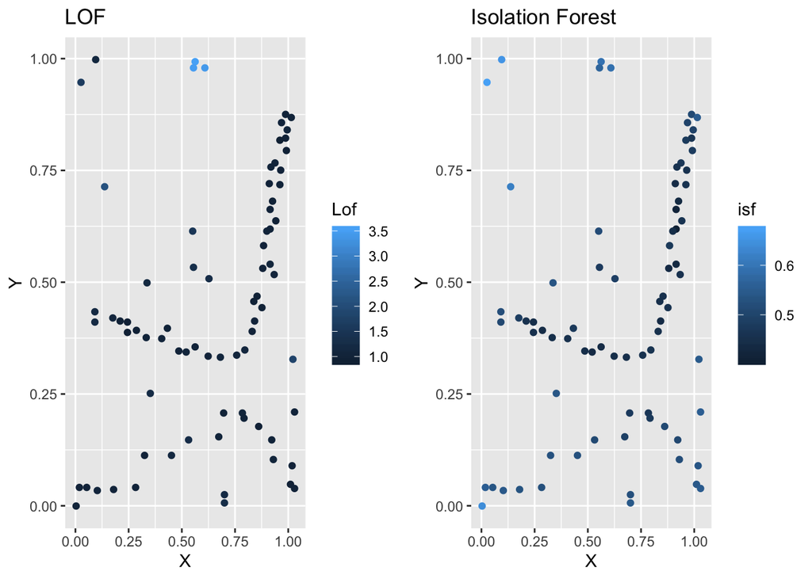

```r
isfscores <- isf$scores
outlier.data$lof <- Lof
outlier.data$isf <- isfscores$anomaly_score
library(ggplot2)
library(gridExtra)
plof <- qplot(x = X,y = Y,data = outlier.data,color = Lof) + ggtitle("LOF")
pisf <- qplot(x=X,y=Y,data = outlier.data,color = isf) + ggtitle("Isolation Forest")

grid.arrange(plof,pisf,nrow=1)
```

## Question 9 : Why do we want a high Breakdown Point?

Because we want to deal with robust statistics. An estimate with a high BDP would need many influential outliers to be a bad estimator, which is good for modelling.

## Question 10: In what ways is the influence function a different measure of resistance for an estimator?

The influence function is a measure of the dependence of the estimator on the value of one of the points in the sample. It is a model-free measure in the sense that it simply relies on calculating the estimator again with a different sample. Rather than the estimator as a whole. The influence function is also a measure of local robustness rather than global robustness.